# Practical: Visualizing model results

Physalia workshop on GLMs

Bert van der Veen

# Background

At this point in the workshop we have covered 1) Sampling variation and maximum likelihood estimation, 2) Simple linear regression, 3) Multiple linear regression, and 4) Checking model assumptions. With this practical, we will end the second day of the workshop with something fun: making nice plots of our data and model results. Let’s start by simulating an example again:

```r
x <- runif(20, 3, 5)
z <- factor(rbinom(20, 1, 0.5), labels = c("group 1", "group 2"))
(y <- rnorm(20, mean = as.integer(z)*2 + x*(as.integer(z)-1)*4 + x*-1))
```

```
##  [1] 11.717014 13.225907 18.138434 15.339021 15.920376 13.714345 14.666416
##  [8] -1.674449 19.492442 14.118910 -2.847454 18.345513 18.835557 14.774407
## [15] -1.586339 -1.597601 -3.258584 -1.302188 16.653857 18.166903
```

Here, $\textbf{z}$ is a categorical predictor and $\textbf{x}$ a continuous predictor. The simulated linear regression includes an interaction of a categorical and a continuous predictor. We should plot the data before we analyse it, so we have a better understanding what is going on:

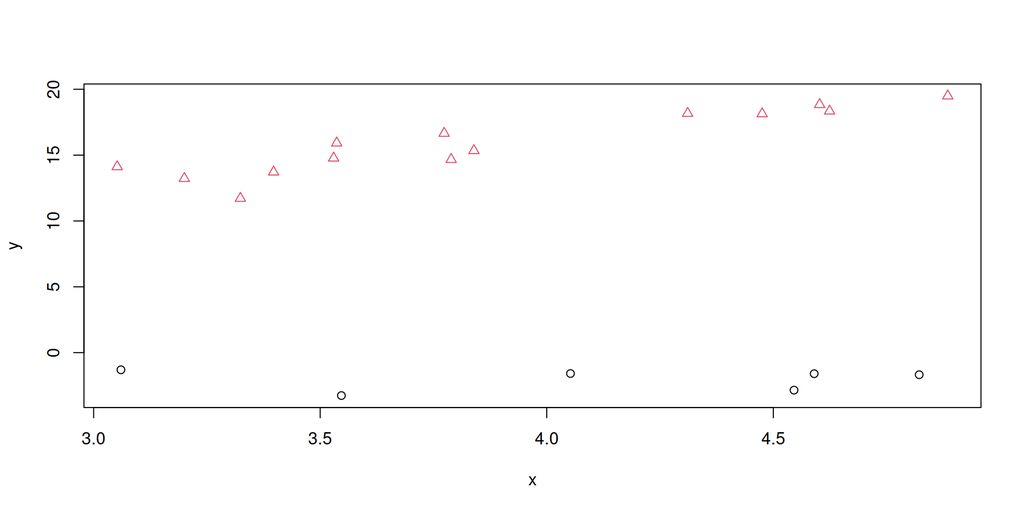

```r
plot(y~x, pch = as.integer(z), col = as.integer(z))
```

Factor variables can be treated as numeric using `as.integer`, which gives each factor the number associated to its level (in alphabetical order). In the plot, the $\textbf{x}$ covariate is shown on the horizontal axis, and the $\textbf{z}$ variable is used to show the groups. Now, we can fit linear models to the data. We will fit three: 1) `y ~ x`, 2) `y ~ x + z`, 3) `y ~ x*z`. Of course we know that the “true” model is 3), but trying different options can help to train your intuition in goodness of fit.

Visualizing data, and model results, are a key component in analysing data; with GLMs or otherwise. Before model fitting, visualizing data can help to inform us of any issues that may arise: non-linearity, outliers or otherwise. After model fitting, we can visualize the prediction to check the model’s fit, or just to present the results for publication. Ideally, such plots include a measure of uncertainty. The `predict` function helps us with this; it has an argument called `newdata` that we can use to create a line for the predictions by passing it many values between the minimum and maximum of $\textbf{x}$, as well as a `se.fit` argument that helps us to construct confidence intervals for the prediction. You can read more about these options in the help page for predicting with linear model objects `?predict.lm`.

First, we use the functions `seq`; “sequence” and `expand.grid` to interpolate between our data. We need this to construct our plot:

```r
xnew <- seq(from = min(x), to = max(x), length.out = 100)
znew <- factor(c("group 1", "group 2"))
newdata <- expand.grid(x = xnew, z = znew)
```

`seq` constructs a sequence of values between the lowest value of $\textbf{x}$ `min(x)` and its highest value `max(x)`. We could use the model to extrapolate, but we do not do that here. Next, we fit the regressions:

```r
reg1 <- lm(y~x)
reg2 <- lm(y~x+z)
reg3 <- lm(y~x*z)
```

The `predict` function always requires all variables in the model to be present in `newdata`. We can choose to fix some of these to a single value, for example, we could predict only for $z = 0$, or we could fix $x$ to its mean (or some other value). Here, we combine the two, which is what `expand.grid` helps us do. It repeats `xnew` for every value of `znew` so we can create a smooth looking plot:

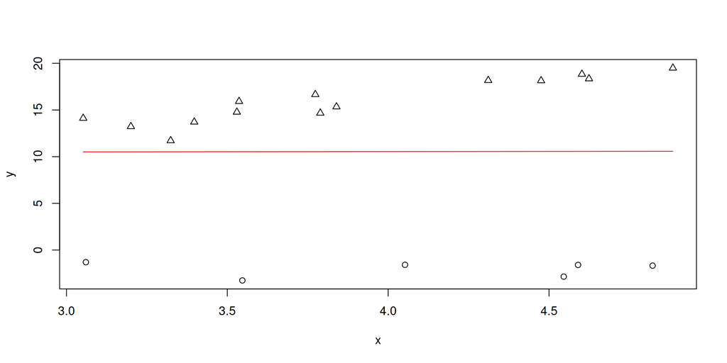

```r
predictions1 <- predict(reg1, newdata = newdata)
plot(y ~ x, ylim = range(c(y, predictions1)), pch = as.integer(z))
lines(predictions1 ~ newdata$x, col = "red")
```

The argument `ylim` helps to ensure that both the predictions and the response variable are in the range of the vertical axis. The predictions are then plotted with the `lines` function, we could alternatively use `points` here, but it makes more sense to visualize a regression using `lines`. The plot looks a bit odd: the regression is not a good fit, it misses vital structure in the data, namely due to $\textbf{z}$. We can make the same plot for the other two models, but we need to plot one line per category $\textbf{z}$:

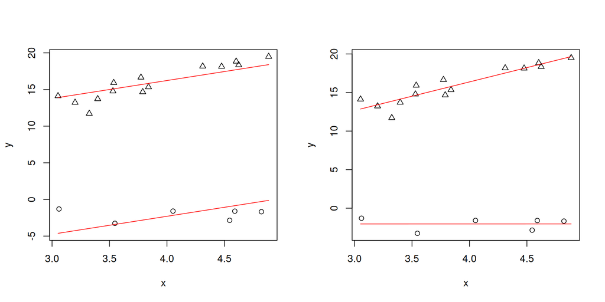

```r
par(mfrow=c(1,2))
predictions2 <- predict(reg2, newdata = newdata)
plot(y ~ x, ylim = range(c(y, predictions2)), pch = as.integer(z))
lines(predictions2[newdata$z=="group 1"] ~ xnew, col = "red")
lines(predictions2[newdata$z=="group 2"] ~ xnew, col = "red")

predictions3 <- predict(reg3, newdata = newdata)
plot(y ~ x, ylim = range(c(y, predictions3)), pch = as.integer(z))
lines(predictions3[newdata$z=="group 1"] ~ xnew, col = "red")
lines(predictions3[newdata$z=="group 2"] ~ xnew, col = "red")
```

The second regression assumes that the two groups have the same $\beta$ for $\textbf{x}$, which means that the regression fits neither group particularly well. It is a considerable improvement from the first model though. The third and final model, which follows the real structure in the data, clearly fits best.

Now, we have not yet added uncertainty to the predictions. For this, we need the `se.fit` argument in the `predict` function. Let’s do this for the third regression:

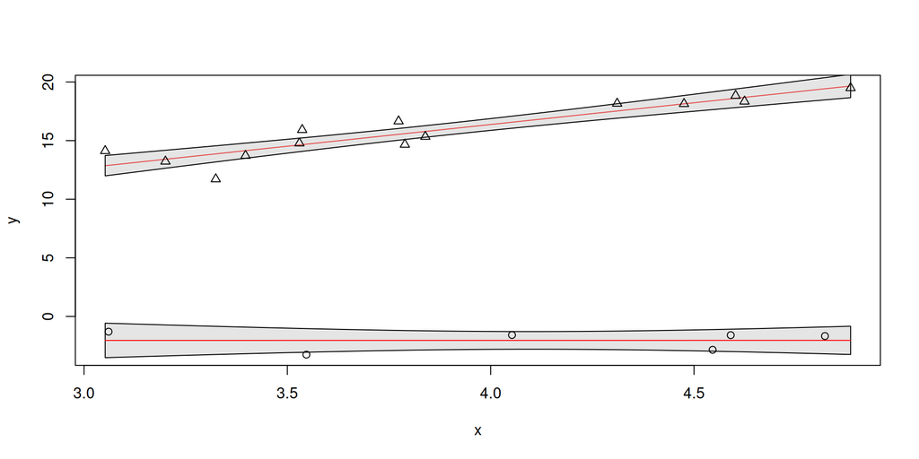

```r
predictions3 <- predict(reg3, newdata = newdata, se.fit = TRUE)
plot(y ~ x, ylim = range(c(y, predictions3)), type = "n")
predictions3$LI <- predictions3$fit - predictions3$se.fit*1.96
predictions3$UI <- predictions3$fit + predictions3$se.fit*1.96

polygon(c(newdata$x[newdata$z=="group 1"], rev(newdata$x[newdata$z=="group 1"])),
        c(predictions3$LI[newdata$z=="group 1"], rev(predictions3$UI[newdata$z=="group 1"])),
        , col = adjustcolor("grey", 0.4))
lines(predictions3$fit[newdata$z=="group 1"] ~ xnew, col = "red")

lines(predictions3$fit[newdata$z=="group 2"] ~ xnew, col = "red")
polygon(c(newdata$x[newdata$z=="group 2"], rev(newdata$x[newdata$z=="group 2"])),
        c(predictions3$LI[newdata$z=="group 2"], rev(predictions3$UI[newdata$z=="group 2"])),
        , col = adjustcolor("grey", 0.4))

points(y~x, pch = as.integer(z))
```

That is a lot of code! The confidence intervals are drawn assuming the estimator for $\hat{\boldsymbol{\mu}}$ is normally distributed, which we know is the case if the right assumptions for our model hold true. In `plot` the `type` argument is used to prevent plotting; vector graphics are layered and we do not want to draw on top of our points, but to have our points on top, so they need to be drawn last. The `polygon` function is used to draw the confidence interval bands, and `adjustcolor` to introduce some transparency to its fill color. Finally, `points` is used to draw the observations, and the `pch` argument adjusts the point shape using $\textbf{z}$

Now that we have visualized the model, we can still visualize the coefficients of the model. This is most straightforwardly done with a caterpillar plot via `stripchart`. We use the `coef` function to extract the parameter estimates, and the `confint` function for the confidence intervals:

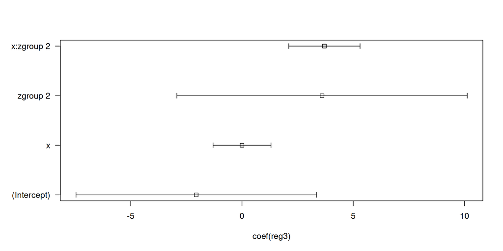

```r
par(mar = c(5, 6, 4, 2))
CI <- confint(reg3)
stripchart(coef(reg3)~factor(names(coef(reg3)), levels = names(coef(reg3))), las = 1, xlim = c(min(CI), max(CI)))
arrows(x0 = CI[,1], x1 = CI[,2], y0 = 1:nrow(CI), y1 = 1:nrow(CI), angle = 90, code = 3, length = 0.05)
```

`par` makes sure we have enough space on the left side of the plot for the labels, `las` turns the labels to be horizontal, and `xlim` adjusts the range of the horizontal axis to ensure that all confidence intervals are fully shown. We use the `arrows` function to draw the confidence intervals, although we could have used the `segments` function instead.

This is a lot of work, and there are plenty of packages that can make your life easier by taking this work out of your hands. Here are a few that you might like to explore during this practical:

- `car`: `avPlots`
- `lattice`: `xyplot`, `dotplot`, `barchart`, `stripplot`, `bwplot`, more
- `emmeans`: function for comparing levels of a categorical predictor. Main function `emmeans`, of which the results can be plotted via `plot(emmeans(...))`
- `visreg`: package dedicated to visualizing regression (see main function `visreg`)
- `effects`: generic function for automatic plotting model results. See function `allEffects` which is plotted via `plot(allEffects(model))`
- `ggeffects`: similar to the effects package, but with ggplot2. Maybe function `ggeffect`
- `arm`: package with loads of tools for regression. `Coefplot` creates a caterpillar plot of model coefficients
- `MuMIn`: package for model selection and averaging. `Coefplot` creates a caterpillar plot of model coefficients
- `ggplot2`: generic package for flexible plotting, main function `ggplot`
- `patchwork`: facilitates combining multiple ggplots

# Part 1

The goal is to have a little fun, while making visualizations that effectively communicate the results of your regression.

Here is what I want you to do:

1. Make a plot of your data and the prediction. For a multiple linear regression, you may want to try for various predictor variables. $\textbf{x}$.
2. Change the point shape, size, and color of the observations.
3. Change the line width and color for the regression.
4. How could you make a plot of the prediction if you have two continuous covariates in the model?
5. Construct a caterpillar plot.
6. Use `par(mfrow=c(..,..))` to plot multiple base R plots together.
7. Use `effects::allEffects` or `ggeffects::ggeffect` to visualize your regression.

# Part 2

Try reconstructing your plots from part 1 using the `ggplot2` package. You need the `ggplot` function in combination with `geom_line` and `geom_ribbon`, `geom_point` and `geom_errorbar`

[If you finish early you can pick a different dataset, or there is also the practical from last year.](https://htmlpreview.github.io/?https://github.com/BertvanderVeen/GLM-workshop/blob/main/Practicals/2024/5Practical.html)